# Nonparametric Regression (ELMR Chapter 14)

Biostat 200C

Dr. Hua Zhou @ UCLA

May 26, 2020

```r
library(tidyverse)
library(faraway)
```

## Parametric vs nonparametric models

- Given a regressor/predictor $x_1,\ldots,x_n$ and response $y_1, \ldots, y_n$, where
  $$y_i = f(x_i) + \epsilon_i,$$
  where $\epsilon_i$ are iid with mean zero and unknown variance $\sigma^2$.
- Parametric approach assumes that $f(x)$ belongs to a parametric family $f(x \mid \boldsymbol{\beta})$. Examples are
  $$\begin{eqnarray*}
  f(x \mid \boldsymbol{\beta}) &=& \beta_0 + \beta_1 x \\
  f(x \mid \boldsymbol{\beta}) &=& \beta_0 + \beta_1 x + \beta_2 x^2 \\
  f(x \mid \boldsymbol{\beta}) &=& \beta_0 + \beta_1 x^{\beta_2}.
  \end{eqnarray*}$$
- Nonparametric approach assumes $f$ is from some smooth family of functions.
- Three datasets.
  - `exa`: $f(x) = \sin^3 (2 \pi x^3)$.

```r
exa <- as_tibble(exa) %>% print()
```

```
## # A tibble: 256 x 3
##          x       y     m
##      <dbl>   <dbl> <dbl>
##  1 0.00480 -0.0339     0
##  2 0.0086   0.165      0
##  3 0.0117   0.0245     0
##  4 0.017    0.178      0
##  5 0.0261  -0.347      0
##  6 0.0299  -0.755      0
##  7 0.0307   0.355      0
##  8 0.0315   0.0401     0
##  9 0.0331   0.106      0
## 10 0.034    0.122      0
## # … with 246 more rows
```

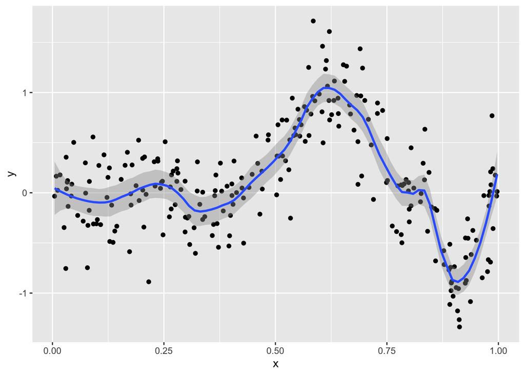

```
- `exb`: $f(x) = 0$.
```

```r
exa %>%
  ggplot(mapping = aes(x = x, y = y)) +
  geom_point() +
  geom_smooth(span = 0.2) # small span give more wiggleness
```

```r
exb <- as_tibble(exb) %>% print()
```

```
## # A tibble: 50 x 3
##        x       y     m
##    <dbl>   <dbl> <dbl>
##  1  0.02  0.781      0
##  2  0.04  1.64       0
##  3  0.06 -0.363      0
##  4  0.08 -0.0540     0
##  5  0.1  -0.804      0
##  6  0.12  0.907      0
##  7  0.14 -0.843      0
##  8  0.16 -0.229      0
##  9  0.18 -0.499      0
## 10  0.2   1.20       0
## # … with 40 more rows
```

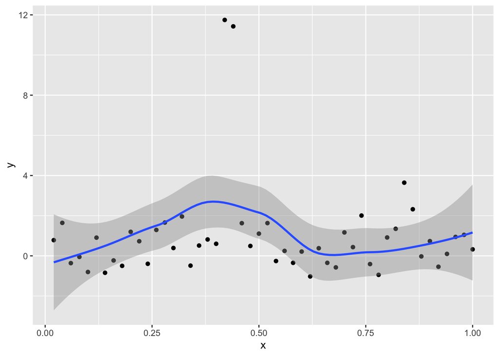

```
- `faithful`: data on Old Faithful geyser in Yellowstone National Park.
```

```r
exb %>%
  ggplot(mapping = aes(x = x, y = y)) +
  geom_point() +
  geom_smooth() # small span give more wiggleness
```

```r
faithful <- as_tibble(faithful) %>% print()
```

```
## # A tibble: 272 x 2
##    eruptions waiting
##        <dbl>   <dbl>
##  1      3.6       79
##  2      1.8       54
##  3      3.33      74
##  4      2.28      62
##  5      4.53      85
##  6      2.88      55
##  7      4.7       88
##  8      3.6       85
##  9      1.95      51
## 10      4.35      85
## # … with 262 more rows
```

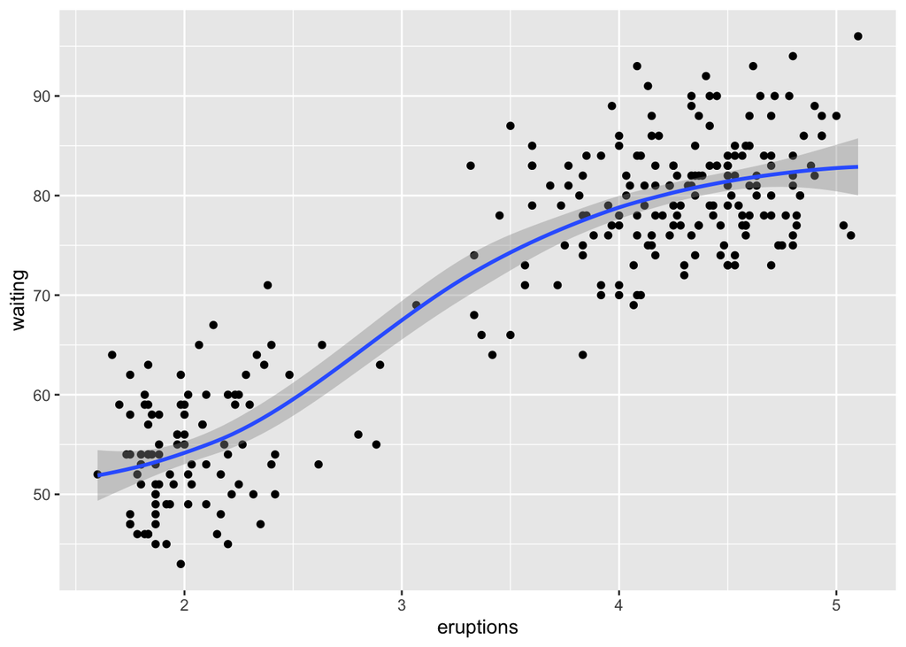

```r
faithful %>%
  ggplot(mapping = aes(x = eruptions, y = waiting)) +
  geom_point() +
  geom_smooth() # small span give more wiggleness
```

## Kernel estimators

- Moving average estimator
  $$\hat f_\lambda(x) = \frac{1}{n\lambda} \sum_{j=1}^n K\left( \frac{x-x_j}{\lambda} \right) Y_j = \frac{1}{n} \sum_{j=1}^n w_j Y_j,$$
  where
  $$w_j = \lambda^{-1} K\left( \frac{x-x_j}{\lambda} \right),$$
  and $K$ is a **kernel** such that $\int K(x) \, dx = 1$. $\lambda$ is called the **bandwidth**, **window width** or **smoothing parameter**.
- When $x$s are spaced unevenly, the kernel estimator can give poor results. This is improved by the **Nadaraya-Watson** estimator
  $$f_\lambda(x) = \frac{\sum_{j=1}^n w_j Y_j}{\sum_{j=1}^n w_j}.$$
- Asymptotics of kernel estimators
  $$\text{MSE}(x) = \mathbb{E} [f(x) - \hat f_\lambda(x)]^2 = O(n^{-4/5}).$$
  Typical parametric estimator has $\text{MSE}(x) = O(n^{-1})$ *if the parametric model is correct*.
- Choice of kernel. Ideal kernel is smooth, compact, and amenable to rapid computation. The optimal choice under some standard assumptions is the Epanechnikov kernel
  $$K(x) = \begin{cases}
  \frac 34 (1 - x^2) & |x| < 1 \\
  0 & \text{otherwise}
  \end{cases}.$$
- Choice of smoothing parameter $\lambda$. Small $\lambda$ gives more wiggly curves, while large $\lambda$ yields smoother curves.

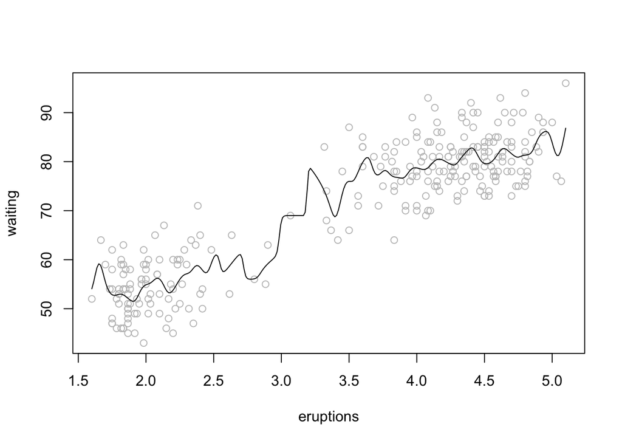

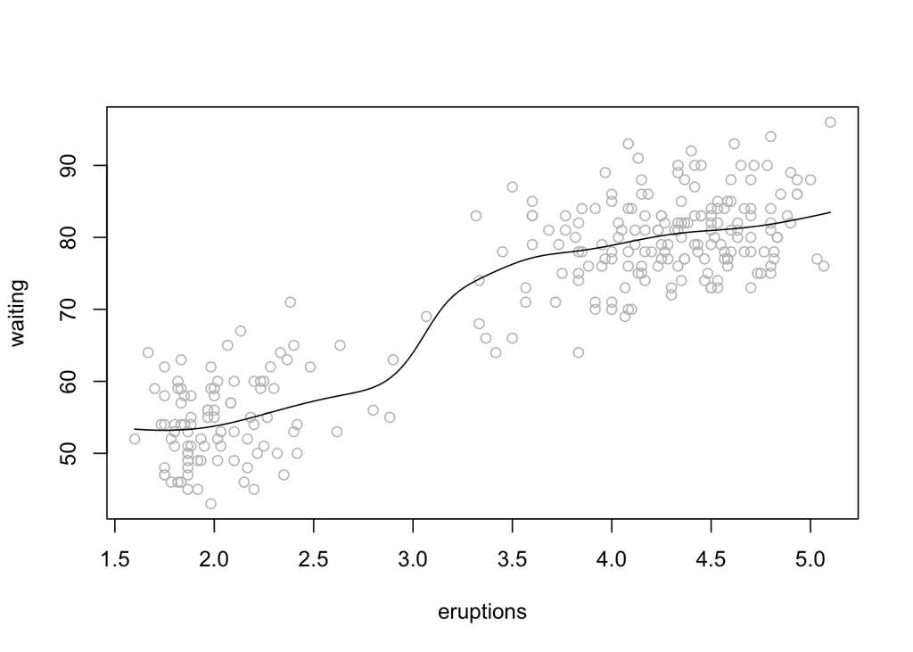

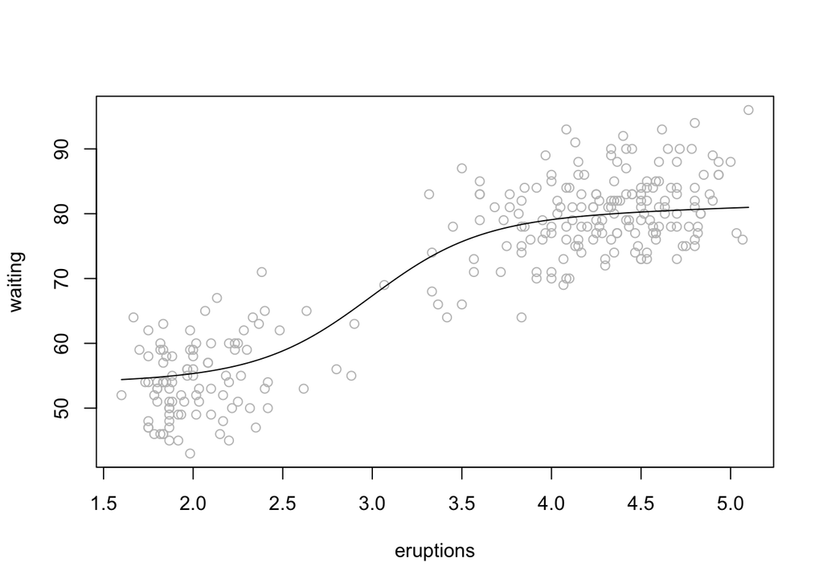

```r
for (bw in c(0.1, 0.5, 2)) {
  with(faithful, {
    plot(waiting ~ eruptions, col = gray(0.75))
    lines(ksmooth(eruptions, waiting, "normal", bw))
  })
}
```

- Cross-valiation (CV) choose the $\lambda$ that minimizes the criterion
  $$\text{CV}(\lambda) = \frac 1n \sum_{j=1}^n [y_j - \hat f_{\lambda(j)})(x_j)]^2,$$
  where $(j)$ indicates that point $j$ is left out of the fit.

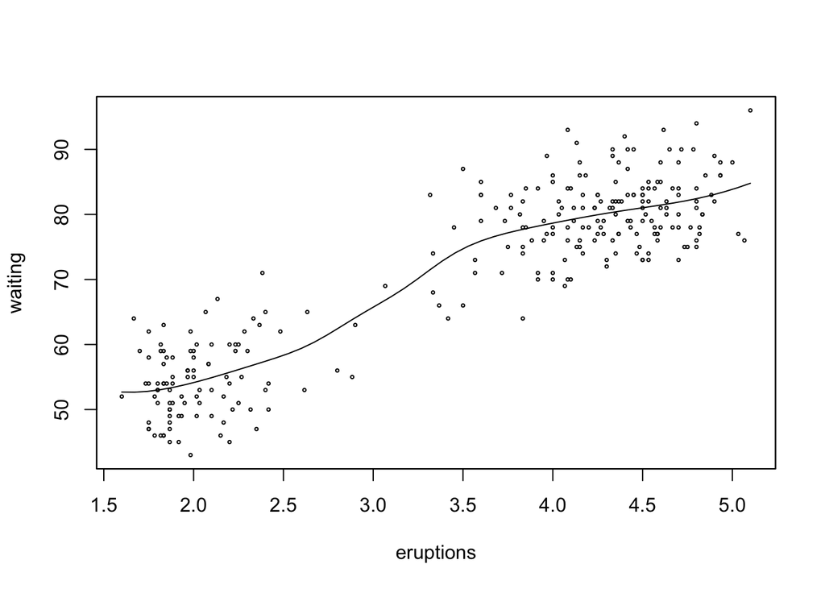

```r
library(sm)
with(faithful,
     sm.regression(eruptions, waiting, h=h.select(eruptions, waiting)))
```

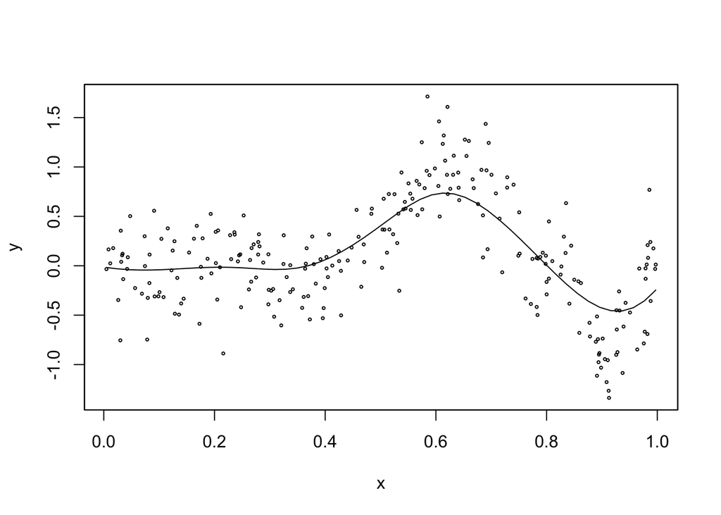

```r
with(exa, sm.regression(x, y, h = h.select(x, y)))
```

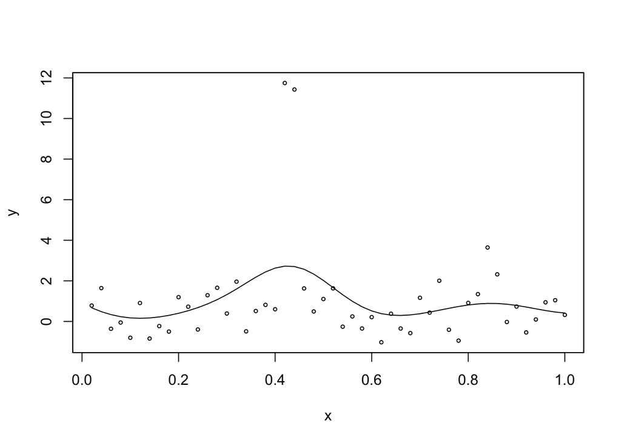

```r
with(exb, sm.regression(x, y, h = h.select(x, y)))
```